# Getting Started with Stan: A Hands-On Introduction to the 8 Schools Problem

Lu Zhang

2023-01-26

Stan is a state-of-the-art platform for statistical modeling and high-performance statistical computation. It works like WinBUGS and JAGS, but Stan uses a method called Hamiltonian Monte Carlo (HMC) for Markov Chain Monte Carlo (MCMC) sampling. Despite being built in C++, Stan is user-friendly and does not require any prior knowledge of C++ to utilize. The Stan language can be accessed through a variety of interfaces, including R, Python, Matlab, Julia, and Stata. In this seminar, we will explore the capabilities of Stan by conducting a Bayesian Data Analysis using the well-known example of the “eight schools” problem.

## 0.1 Installation

To install Stan, search for “Stan Bayesian” on Google to access the home page. Navigate to the installation page. There are two R interfaces to Stan, Rstan and CmdStanR. According to the CmdStanR tutorial: [Getting started with CmdStanR](https://mc-stan.org/cmdstanr/articles/cmdstanr.html),

“The RStan interface (RStan package) is an in-memory interface to Stan and relies on R packages like Rcpp and inline to call C++ code from R. On the other hand, the CmdStanR interface does not directly call any C++ code from R, instead relying on the CmdStan interface behind the scenes for compilation, running algorithms, and writing results to output files.”

I highly recommend CmdStanR over RStan, as it is compatible with the latest versions of Stan. RStan may fall behind in terms of updates, as the process of keeping up with the latest Stan releases often entails non-trivial modifications to the RStan package and new releases on CRAN for both RStan and StanHeaders.

# 1 Example: 8 Schools problem

The eight schools problem is a famous example of a hierarchical model in statistics illustrated in Chapter 5 of Gelman’s Bayesian Data Analysis (BDA) book. The story is about a study for the Education Testing Service to analyze the effects of special coaching programs on test scores. There are 8 different schools experimented with an SAT coaching experiment. In each school, the estimated coaching effect $y_j$ and its standard error $\sigma_j$ were obtained by an analysis of covariance adjustment appropriate for a completely randomized experiment. (Check BDA for more details)

Here are the data:

```r
Schools <- data.frame(row.names=c("A","B","C","D","E","F","G","H"),
                      effect = c(28, 8, -3, 7, -1, 1, 18, 12),
                      see = c(15, 10, 16, 11, 9, 11, 10, 18))

Schools
```

```
  effect see
A     28  15
B      8  10
C     -3  16
D      7  11
E     -1   9
F      1  11
G     18  10
H     12  18
```

The goal of the analysis is to estimate the average treatment effect of a coaching program on student test scores.

## 1.1 Modeling of the 8-school problem

Define $\theta_j : j= 1, \ldots, 8$ as the treatment effect in school $j$. Let $\mu$ and $\tau$ be mean and standard deviation of the treatment effects $\theta_j$. We build a hierarchical model:

$$\begin{align}
y_j &= \theta_j + \epsilon_j \;, \; \epsilon_j \sim \mbox{N}(0,
\sigma_j^2) \\
\theta_j &\sim \mbox{N}(\mu, \tau^2)
\end{align}$$

For hyper parameters $\mu$ and $\tau$, we assign a normal prior for $\mu$ and a half-Cauchy prior for $\tau$.
$$\mu \sim \mbox{N}(0, 5^2)\; , \; \tau \sim \mbox{Cauchy}^+(0, 5^2)$$
The Stan development team has created an informative Wiki page that guides users on how to choose appropriate priors when building Bayesian models.

[Stan Prior Choice Recommendations Wiki page](https://github.com/stan-dev/stan/wiki/Prior-Choice-Recommendations)

I highly recommend consulting this resource when constructing your own models, as it will provide valuable insights and best practices.

# 2 Stan’s program blocks

The Stan modeling language uses a block structure to organize model code. The three main blocks in a Stan program are the `data` block, the `parameters` block, and the `model` block.

## 2.1 The `data` block

The `data` block is where the data that the model will be fitted to is defined. In here we express how the data list should look like, with data type and restrictions. Inside it, number of schools J is declared as an integer, with the restriction that it can not be lower than 0. A semicolon at the end of each line means that the command has ended. This semicolon is required at the end of every command in Stan. To make a comment, we use double slash. Now, y is a vector of real numbers with length J and sigma is a vector of real numbers with length J with the restriction that lower value of standard errors sigma can be 0.

```r
data {
  int <lower=0> J; // number of schools
  array[J] real y; // estimated treatment
  array[J] real<lower=0> sigma; // std of estimated effect
}
```

## 2.2 The `parameters` block

The `parameters` block is where we define the sampling space. Here we put the parameters of interest. Mean mu, population standard deviation tau are scalar with tau having a non-negative restriction. And theta is a vector with J elements.

```r
parameters {
  array[J] real theta; // treatment effect in school j
  real mu; // hyper-parameter of mean
  real<lower=0> tau; // hyper-parameter of sdv
}
```

## 2.3 The `model` block

The `model` block describes the model; that includes priors and likelihoods. Here y is modeled by normal with mean theta and standard deviation sigma, theta is hierarchically modeled by normal with mean mu and standard deviation tau. And the priors for tau and mu are half-Cauchy and normal, respectively.

```r
model {
  tau ~ cauchy(0, 5); // a non-informative prior
  theta ~ normal(mu, tau);
  y ~ normal(theta, sigma);
  mu ~ normal(0, 5);
}
```

Putting all of these blocks together defines a full Stan program.

```r
writeLines(readLines("./stan/eight_schools_centered.stan"))
```

```
data {
  int <lower=0> J; // number of schools
  array[J] real y; // estimated treatment
  array[J] real<lower=0> sigma; // std of estimated effect
}

parameters {
  array[J] real theta; // treatment effect in school j
  real mu; // hyper-parameter of mean
  real<lower=0> tau; // hyper-parameter of sdv
}

model {
  tau ~ cauchy(0, 5); // a non-informative prior
  theta ~ normal(mu, tau);
  y ~ normal(theta, sigma);
  mu ~ normal(0, 5);
}
```

## 2.4 Overview of Stan’s program blocks

In addition to the `data`, `parameters`, and `model` blocks, Stan offers a wider range of program blocks. A complete list of these named blocks can be found in the following skeletal Stan program.

```r
functions {
  // ... function declarations and definitions ...
}
data {
  // ... declarations ...
}
transformed data {
   // ... declarations ... statements ...
}
parameters {
   // ... declarations ...
}
transformed parameters {
   // ... declarations ... statements ...
}
model {
   // ... declarations ... statements ...
}
generated quantities {
   // ... declarations ... statements ...
}
```

The function-definition block contains user-defined functions. The data block declares the required data for the model. The transformed data block allows the definition of constants and transforms of the data. The parameters block declares the model’s parameters — the unconstrained version of the parameters is what’s sampled or optimized. The transformed parameters block allows variables to be defined in terms of data and parameters that may be used later and will be saved. The model block is where the log probability function is defined. The generated quantities block allows derived quantities based on parameters, data, and optionally (pseudo) random number generation.

All of the blocks are optional. The Stan program blocks that occur must occur in the order presented in the skeletal program above.

# 3 Fit 8-school model in Stan

## 3.1 Loading cmdstanr

```r
library(cmdstanr)
check_cmdstan_toolchain(fix = TRUE, quiet = TRUE)
```

## 3.2 Generating data:

```r
data <- list(J = 8,                              # number of schools
             y = c(28, 8, -3, 7, -1, 1, 18, 12),
             sigma = c(15, 10, 16, 11, 9, 11, 10, 18))
```

## 3.3 Compiling the model

The `cmdstan_model()` function creates a new `CmdStanModel` object from a file containing a Stan program. In the following chunk the `CmdStanModel` object is named `mod1`. This step will also generate a compiled executable under the same path of the “.stan” file.

```r
mod1  <- cmdstan_model( "./stan/eight_schools_centered.stan" )
```

Stan will not recompile the model unless the Stan code is changed.

For `CmdStanModel` objects, methods are accessed using the `$` operator. The Stan program can be printed using the `$print()` method:

```r
mod1$print()
```

```
data {
  int <lower=0> J; // number of schools
  array[J] real y; // estimated treatment
  array[J] real<lower=0> sigma; // std of estimated effect
}

parameters {
  array[J] real theta; // treatment effect in school j
  real mu; // hyper-parameter of mean
  real<lower=0> tau; // hyper-parameter of sdv
}

model {
  tau ~ cauchy(0, 5); // a non-informative prior
  theta ~ normal(mu, tau);
  y ~ normal(theta, sigma);
  mu ~ normal(0, 5);
}
```

## 3.4 Running MCMC

The `$sample()` method for CmdStanModel objects runs Stan’s default MCMC algorithm.

Below shows the code for running sampling with cmdstanr.

```r
fit1_stan <- mod1$sample(
    data = data,
    seed = 1,
    refresh = 500,          # print update every 500 iters
    chains=4,
    parallel_chains=4,
    iter_warmup = 1000,
    iter_sampling = 1000,
    adapt_delta = 0.9,
    show_messages = TRUE)
```

The `$sample()’ method has a variety of arguments that can be passed. I will provide information on some of the most useful arguments. For more detailed information on all available arguments, please refer to the separate documentation page ([Run Stan’s MCMC algorithms](https://mc-stan.org/cmdstanr/reference/model-method-sample.html)) provided by the Stan Development Team.

### 3.4.1 Arguments of `$sample()` (Excerpt from [Run Stan’s MCMC algorithms](https://mc-stan.org/cmdstanr/reference/model-method-sample.html))

**data**: (multiple options) The data to use for the variables specified in the data block of the Stan program. One of the following:

- A named list of R objects with the names corresponding to variables declared in the data block of the Stan program. Internally this list is then written to JSON for CmdStan using write_stan_json(). See write_stan_json() for details on the conversions performed on R objects before they are passed to Stan.
- A path to a data file compatible with CmdStan (JSON or R dump). See the appendices in the CmdStan guide for details on using these formats.
- NULL or an empty list if the Stan program has no data block.

**seed**: (positive integer(s)) A seed for the (P)RNG to pass to CmdStan. In the case of multi-chain sampling the single seed will automatically be augmented by the the run (chain) ID so that each chain uses a different `seed`. The exception is the transformed data block, which defaults to using same seed for all chains so that the same data is generated for all chains if RNG functions are used. The only time seed should be specified as a vector (one element per chain) is if RNG functions are used in transformed data and the goal is to generate different data for each chain.

**refresh**: (non-negative integer) The number of iterations between printed screen updates. If $refresh = 0$, only error messages will be printed.

**init**: (multiple options) The initialization method to use for the variables declared in the parameters block of the Stan program. One of the following:

- A real number $x>0$. This initializes all parameters randomly between $[-x,x]$ on the unconstrained parameter space.;
- The number 0. This initializes all parameters to 0;
- A character vector of paths (one per chain) to JSON or Rdump files containing initial values for all or some parameters. See ‘write_stan_json()’ to write R objects to JSON files compatible with CmdStan.
- A list of lists containing initial values for all or some parameters. For MCMC the list should contain a sublist for each chain. For optimization and variational inference there should be just one sublist. The sublists should have named elements corresponding to the parameters for which you are specifying initial values. See Examples.
- A function that returns a single list with names corresponding to the parameters for which you are specifying initial values. The function can take no arguments or a single argument chain_id. For MCMC, if the function has argument chain_id it will be supplied with the chain id (from 1 to number of chains) when called to generate the initial values. See Examples.

**chains**: (positive integer) The number of Markov chains to run. The default is 4.

**parallel_chains**: (positive integer) The maximum number of MCMC chains to run in parallel. If parallel_chains is not specified then the default is to look for the option “mc.cores”, which can be set for an entire R session by options(mc.cores=value). If the “mc.cores” option has not been set then the default is 1.

**iter_warmup**: (positive integer) The number of warmup iterations to run per chain. Note: in the CmdStan User’s Guide this is referred to as num_warmup. The default is 1000.

**iter_sampling**: (positive integer) The number of post-warmup iterations to run per chain. Note: in the CmdStan User’s Guide this is referred to as num_samples. The default is 1000.

### 3.4.2 Arguments for adaptation in Stan

In order to gain a deeper understanding of arguments for adaptation in Stan, it is helpful to know the tuning parameters of HMC sampling algorithms, how Stan adjusts them during the warmup phase [15.2 HMC algorithm parameters](https://mc-stan.org/docs/reference-manual/hmc-algorithm-parameters.html), and how the No-U-Turn Hamiltonian Monte Carlo (NUTS) works [(3.1 No-U-Turn Hamiltonian Monte Carlo)](http://www.stat.columbia.edu/~gelman/research/published/nuts.pdf)

**max_treedepth**: (positive integer) The maximum allowed tree depth for the NUTS engine. See the Tree Depth section of the CmdStan User’s Guide for more details. The default is 10.

**adapt_engaged**: (logical) Do warmup adaptation? The default is TRUE. If a precomputed inverse metric is specified via the inv_metric argument (or metric_file) then, if adapt_engaged=TRUE, Stan will use the provided inverse metric just as an initial guess during adaptation. To turn off adaptation when using a precomputed inverse metric set adapt_engaged=FALSE.

**adapt_delta**: (real in (0,1)) The adaptation target acceptance statistic. The default is 0.8.

**step_size**: (positive real) The initial step size for the discrete approximation to continuous Hamiltonian dynamics. This is further tuned during warmup.

**metric**: (string) One of “diag_e”, “dense_e”, or “unit_e”, specifying the geometry of the base manifold. See the Euclidean Metric section of the CmdStan User’s Guide for more details. To specify a precomputed (inverse) metric, see the inv_metric argument below. The default is “diag_e”

**init_buffer**: (nonnegative integer) Width of initial fast timestep adaptation interval during warmup.

**term_buffer**: (nonnegative integer) Width of final fast timestep adaptation interval during warmup.

**window**(nonnegative integer) Initial width of slow timestep/metric adaptation interval.

**Now let’s run the code and check the messages reported by Stan**

```r
fit1_stan <- mod1$sample(
    data = data,
    seed = 1,
    refresh = 500,          # print update every 500 iters
    chains=4,
    parallel_chains=4,
    iter_warmup = 1000,
    iter_sampling = 1000,
    adapt_delta = 0.9,
    show_messages = TRUE)
```

```
Running MCMC with 4 parallel chains...

Chain 1 Iteration:    1 / 2000 [  0%]  (Warmup)
Chain 1 Iteration:  500 / 2000 [ 25%]  (Warmup)
Chain 1 Iteration: 1000 / 2000 [ 50%]  (Warmup)
Chain 1 Iteration: 1001 / 2000 [ 50%]  (Sampling)
Chain 2 Iteration:    1 / 2000 [  0%]  (Warmup)
Chain 2 Iteration:  500 / 2000 [ 25%]  (Warmup)
Chain 2 Iteration: 1000 / 2000 [ 50%]  (Warmup)
Chain 2 Iteration: 1001 / 2000 [ 50%]  (Sampling)
Chain 2 Iteration: 1500 / 2000 [ 75%]  (Sampling)
Chain 2 Iteration: 2000 / 2000 [100%]  (Sampling)
Chain 3 Iteration:    1 / 2000 [  0%]  (Warmup)
Chain 3 Iteration:  500 / 2000 [ 25%]  (Warmup)
Chain 3 Iteration: 1000 / 2000 [ 50%]  (Warmup)
Chain 3 Iteration: 1001 / 2000 [ 50%]  (Sampling)
Chain 3 Iteration: 1500 / 2000 [ 75%]  (Sampling)
Chain 3 Iteration: 2000 / 2000 [100%]  (Sampling)
Chain 4 Iteration:    1 / 2000 [  0%]  (Warmup)
Chain 4 Iteration:  500 / 2000 [ 25%]  (Warmup)
Chain 4 Iteration: 1000 / 2000 [ 50%]  (Warmup)
Chain 4 Iteration: 1001 / 2000 [ 50%]  (Sampling)
Chain 1 Iteration: 1500 / 2000 [ 75%]  (Sampling)
Chain 1 Iteration: 2000 / 2000 [100%]  (Sampling)
Chain 1 finished in 0.2 seconds.
Chain 2 finished in 0.1 seconds.
Chain 3 finished in 0.2 seconds.
Chain 4 Iteration: 1500 / 2000 [ 75%]  (Sampling)
Chain 4 Iteration: 2000 / 2000 [100%]  (Sampling)
Chain 4 finished in 0.5 seconds.

All 4 chains finished successfully.
Mean chain execution time: 0.2 seconds.
Total execution time: 0.6 seconds.
```

## 3.5 Diagnosing fitting

### 3.5.1 The `$cmdstan_diagnose()` method

The `$cmdstan_diagnose()` method in CmdStan is designed to help identify potential issues with your model through the use of various diagnostic tools and checks. Now let’s check the 8-school model.

```r
fit1_stan$cmdstan_diagnose()
```

```
Processing csv files: /tmp/RtmpIOUolC/eight_schools_centered-202301260014-1-7338f3.csv, /tmp/RtmpIOUolC/eight_schools_centered-202301260014-2-7338f3.csv, /tmp/RtmpIOUolC/eight_schools_centered-202301260014-3-7338f3.csv, /tmp/RtmpIOUolC/eight_schools_centered-202301260014-4-7338f3.csv

Checking sampler transitions treedepth.
Treedepth satisfactory for all transitions.

Checking sampler transitions for divergences.
83 of 4000 (2.08%) transitions ended with a divergence.
These divergent transitions indicate that HMC is not fully able to explore the posterior distribution.
Try increasing adapt delta closer to 1.
If this doesn't remove all divergences, try to reparameterize the model.

Checking E-BFMI - sampler transitions HMC potential energy.
The E-BFMI, 0.21, is below the nominal threshold of 0.30 which suggests that HMC may have trouble exploring the target distribution.
If possible, try to reparameterize the model.

Effective sample size satisfactory.

Split R-hat values satisfactory all parameters.

Processing complete.
```

The following guidance on diagnostics message are excerpt from [Runtime warnings and convergence problems](https://mc-stan.org/misc/warnings.html#divergent-transitions-after-warmup)

- Maximum treedepth

Warnings about hitting the maximum treedepth are not as serious as other warnings. While divergent transitions, high R-hat and low ESS are a validity concern, hitting the maximum treedepth is an efficiency concern. Configuring the No-U-Turn-Sampler (the variant of HMC used by Stan) involves putting a cap on the number of simulation steps it evaluates during each iteration (for details on this see the Hamiltonian Monte Carlo Sampling chapter in the Stan manual). This is controlled through a maximum tree depth parameter max_treedepth where the maximum number of steps is 2^max_treedepth. When the maximum allowed tree depth is reached it indicates that NUTS might be terminating prematurely to avoid excessively long execution time.

If this is the only warning you are getting and your ESS and R-hat diagnostics are good, it is likely safe to ignore this warning, but finding the root cause could result in a more efficient model.

We do not generally recommend increasing max treedepth. In practice, the max treedepth limit being reached can be a sign of model misspecification, and to increase max treedepth can then result in just taking longer to fit a model that you don’t want to be fitting.

- Divergence

Stan uses Hamiltonian Monte Carlo (HMC) to explore the target distribution — the posterior defined by a Stan program + data — by simulating the evolution of a Hamiltonian system. In order to approximate the exact solution of the Hamiltonian dynamics we need to choose a step size governing how far we move each time we evolve the system forward. The step size controls the resolution of the sampler.

For hard problems the curvature of the posterior can vary a lot and there can be features of the target distribution that are too small for this resolution. For example, divergences are likely if the log posterior density doesn’t have continuous derivative everywhere. Consequently the sampler misses those features and returns biased estimates. Fortunately, this mismatch of scales manifests as divergences which provide a practical diagnostic.

Even a small number of divergences after warmup cannot be safely ignored if completely reliable inference is desired. But if you get only few divergences and you get good Rhat and ESS values, the resulting posterior is often good enough to move forward. There are also cases when a small number divergences without any pattern in their locations can be verified to be unimportant, but this cannot be safely assumed without a careful investigation of the model.

- E-BFMI

You may see a warning that says some number of chains had an estimated BFMI that was too low. This implies that the adaptation phase of the Markov chains did not turn out well or the posterior has thick tails that were not well explored in the simulation. As with other warnings, if the BFMI value is just slightly below the threshold, the posterior is likely good for sanity checks but probably still not good for final inferences.

- R-hat

R-hat (sometimes also Rhat) convergence diagnostic compares the between- and within-chain estimates for model parameters and other univariate quantities of interest. If chains have not mixed well (so that between- and within-chain estimates don’t agree), R-hat is larger than 1. We recommend running at least four chains by default and in general only fully trust the sample if R-hat is less than 1.01. In early workflow, R-hat below 1.1 is often sufficient.

Stan reports R-hat as the maximum of rank normalized split-R-hat and rank normalized folded-split-R-hat, which works for thick tailed distributions and is sensitive also to differences in scale.

High R-hat means that the chains have not mixed well and so there is not a good reason to think of them as them being fully representative of the posterior.

When there are divergent transitions in the model, high R-hat is often just another symptom of the problematic geometry that caused the divergences. If there are “maximum treedepth” warnings alongside high R-hat, it usually reflects a problematic geometry of the posterior that is hard to traverse efficiently and is often a side effect of setting very high adapt_delta in an attempt to resolve divergences. High R-hat without other warnings is commonly associated with posteriors that have multiple well-separated modes for the offending parameters, but can also arise in unimodal posteriors with difficult geometry, in case of high correlations, or in near improper posteriors.

R-hat and ESSs (see below) are useful quick summaries, but for the final results, it is useful to check also Monte Carlo standard error for the quantities of interest and compare that to the domain knowledge of the required accuracy, and if it is low, then run longer chains to get more samples from the posterior.

- Bulk and Tail ESS

Roughly speaking, the effective sample size (ESS) of a quantity of interest captures how many independent draws contain the same amount of information as the dependent sample obtained by the MCMC algorithm. The higher the ESS the better. Stan uses R-hat adjustment to use the within- and between-chain information in computing the ESS. For example, in case of multimodal distributions with well-separated modes, this leads to an ESS estimate that is close to the number of distinct modes that are found.

Bulk-ESS refers to the effective sample size based on the rank normalized draws. This does not directly compute the ESS relevant for computing the mean of the parameter, but instead computes a quantity that is well defined even if the chains do not have finite mean or variance. Overall bulk-ESS estimates the sampling efficiency for location summaries such as mean and median. Often smaller ESS would be sufficient for the desired estimation accuracy, but the estimation of ESS and convergence diagnostics themselves require higher ESS. For final results, we recommend requiring that the bulk-ESS is greater than 100 times the number of chains. For example, when running four chains, this corresponds to having a rank-normalized effective sample size of at least 400. In early workflow, ESS > 20 is often sufficient.

Tail-ESS computes the minimum of the effective sample sizes (ESS) of the 5% and 95% quantiles. Tail-ESS can help diagnose problems due to different scales of the chains and slow mixing in the tails.

In most cases, low bulk-ESS and tail-ESS is accompanied by large R-hat, and all recommendations for large Rhat are often useful in dealing with low ESS.

R-hat and ESS are useful quick summaries, but for final results, it can useful to check also Monte Carlo standard error for the quantities of interest and compare that to the domain knowledge of the required accuracy, and if needed then sample from the posterior.

The `$print()’ method provides an overview of default estimators and their associated values, such as the means and quantiles of the individual marginal distributions.

```r
fit1_stan$print()
```

```
 variable   mean median   sd  mad     q5   q95 rhat ess_bulk ess_tail
 lp__     -15.04 -15.52 6.64 6.66 -25.29 -3.44 1.03      152      156
 theta[1]   6.32   5.72 5.62 4.58  -1.49 16.20 1.00      786      972
 theta[2]   4.91   4.84 4.67 4.40  -2.24 12.52 1.01      785     1492
 theta[3]   3.72   3.97 5.47 4.44  -5.41 11.88 1.00      808     1263
 theta[4]   4.70   4.76 5.03 4.39  -3.34 12.61 1.00      894     1724
 theta[5]   3.46   3.84 4.78 4.30  -4.67 10.63 1.00      768     1787
 theta[6]   3.89   4.06 4.93 4.31  -4.24 11.49 1.00      711     1965
 theta[7]   6.41   5.94 5.22 4.33  -0.97 15.52 1.00      779     1489
 theta[8]   4.87   4.87 5.43 4.57  -3.61 13.45 1.00     1072     1798
 mu         4.31   4.36 3.22 3.32  -0.98  9.53 1.01      442     1341

 # showing 10 of 11 rows (change via 'max_rows' argument or 'cmdstanr_max_rows' option)
```

- **Further reading on improving the 8-school model by reparametrization** [Diagnosing Biased Inference with Divergences](https://mc-stan.org/users/documentation/case-studies/divergences_and_bias.html)

### 3.5.2 Other diagnostics methods

The `$sampler_diagnostics()` method extracts the values of the sampler parameters (treedepth__, divergent__, etc.) in formats supported by the posterior package.

```r
fit1_stan$sampler_diagnostics()
```

```
# A draws_array: 1000 iterations, 4 chains, and 6 variables
, , variable = treedepth__

         chain
iteration 1 2 3 4
        1 6 4 4 4
        2 6 4 4 3
        3 6 4 3 3
        4 5 4 3 3
        5 6 4 3 3

, , variable = divergent__

         chain
iteration 1 2 3 4
        1 0 0 0 0
        2 0 0 0 0
        3 0 0 0 0
        4 0 0 0 0
        5 0 0 0 0

, , variable = energy__

         chain
iteration  1  2  3      4
        1 37 24 20  2.807
        2 37 27 14  1.316
        3 32 30 14 -0.098
        4 26 24 12  0.363
        5 30 22 11  1.074

, , variable = accept_stat__

         chain
iteration    1    2    3    4
        1 0.97 0.95 1.00 0.98
        2 1.00 0.85 0.99 0.95
        3 1.00 0.99 0.96 1.00
        4 0.99 0.93 0.94 0.68
        5 0.97 1.00 0.73 0.92

# ... with 995 more iterations, and 2 more variables
```

The `$diagnostic_summary()` method will display any sampler diagnostic warnings and return a summary of diagnostics for each chain.

```r
fit1_stan$diagnostic_summary()
```

```
Warning: 83 of 4000 (2.0%) transitions ended with a divergence.
See https://mc-stan.org/misc/warnings for details.
```

```
Warning: 2 of 4 chains had an E-BFMI less than 0.2.
See https://mc-stan.org/misc/warnings for details.
```

```
$num_divergent
[1] 18 44 21  0

$num_max_treedepth
[1] 0 0 0 0

$ebfmi
[1] 0.1827177 0.2749811 0.1954507 0.2062653
```

## 3.6 Useful diagnostic and summary functions.

Load the bayesplot and posterior packages in order to access additional diagnostic and summary functions.

```r
library(bayesplot)
library(posterior)
color_scheme_set("brightblue")
```

### 3.6.1 Summaries from the posterior package

The `$summary()` method calls summarise_draws() from the posterior package. The first argument specifies the variables to summarize and any arguments after that are passed on to `posterior::summarise_draws()` to specify which summaries to compute, whether to use multiple cores, etc.

```r
fit1_stan$summary()
```

```
# A tibble: 11 × 10
   variable   mean median    sd   mad      q5   q95  rhat ess_bulk ess_tail
   <chr>     <dbl>  <dbl> <dbl> <dbl>   <dbl> <dbl> <dbl>    <dbl>    <dbl>
 1 lp__     -15.0  -15.5   6.64  6.66 -25.3   -3.44  1.03     152.     156.
 2 theta[1]   6.32   5.72  5.62  4.58  -1.49  16.2   1.00     787.     972.
 3 theta[2]   4.91   4.84  4.67  4.40  -2.24  12.5   1.01     785.    1493.
 4 theta[3]   3.72   3.97  5.47  4.44  -5.41  11.9   1.00     808.    1264.
 5 theta[4]   4.70   4.76  5.03  4.39  -3.34  12.6   1.00     895.    1725.
 6 theta[5]   3.46   3.84  4.78  4.30  -4.67  10.6   1.00     768.    1788.
 7 theta[6]   3.89   4.06  4.93  4.31  -4.24  11.5   1.00     712.    1966.
 8 theta[7]   6.41   5.94  5.22  4.33  -0.970 15.5   1.00     779.    1489.
 9 theta[8]   4.87   4.87  5.43  4.57  -3.61  13.5   1.00    1073.    1798.
10 mu         4.31   4.36  3.22  3.32  -0.979  9.53  1.01     443.    1341.
11 tau        3.96   3.15  3.21  2.55   0.554 10.3   1.03     152.     112.
```

```r
fit1_stan$summary(variables = c("theta"), "mean", "sd")
```

```
# A tibble: 8 × 3
  variable  mean    sd
  <chr>    <dbl> <dbl>
1 theta[1]  6.32  5.62
2 theta[2]  4.91  4.67
3 theta[3]  3.72  5.47
4 theta[4]  4.70  5.03
5 theta[5]  3.46  4.78
6 theta[6]  3.89  4.93
7 theta[7]  6.41  5.22
8 theta[8]  4.87  5.43
```

### 3.6.2 Extracting draws

The `$draws()` method can be used to extract the posterior draws in formats provided by the posterior package.

```r
# default is a 3-D draws_array object from the posterior package
# iterations x chains x variables
draws_arr <- fit1_stan$draws() # or format="array"
str(draws_arr)
```

```
##  'draws_array' num [1:1000, 1:4, 1:11] -32.1 -24.7 -23 -21.8 -24.7 ...
##  - attr(*, "dimnames")=List of 3
##   ..$ iteration: chr [1:1000] "1" "2" "3" "4" ...
##   ..$ chain    : chr [1:4] "1" "2" "3" "4"
##   ..$ variable : chr [1:11] "lp__" "theta[1]" "theta[2]" "theta[3]" ...
```

### 3.6.3 Plotting draws using the bayesplot package

Plotting posterior distributions is as easy as passing the object returned by the `$draws()` method directly to plotting functions in the bayesplot package.

**Histogram**

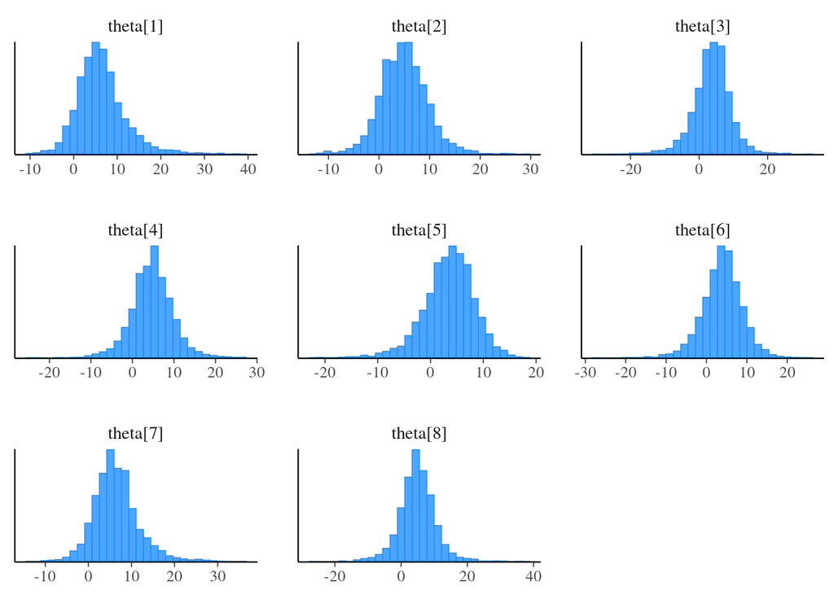

```r
mcmc_hist(fit1_stan$draws("theta"))
```

**MCMC traceplot**

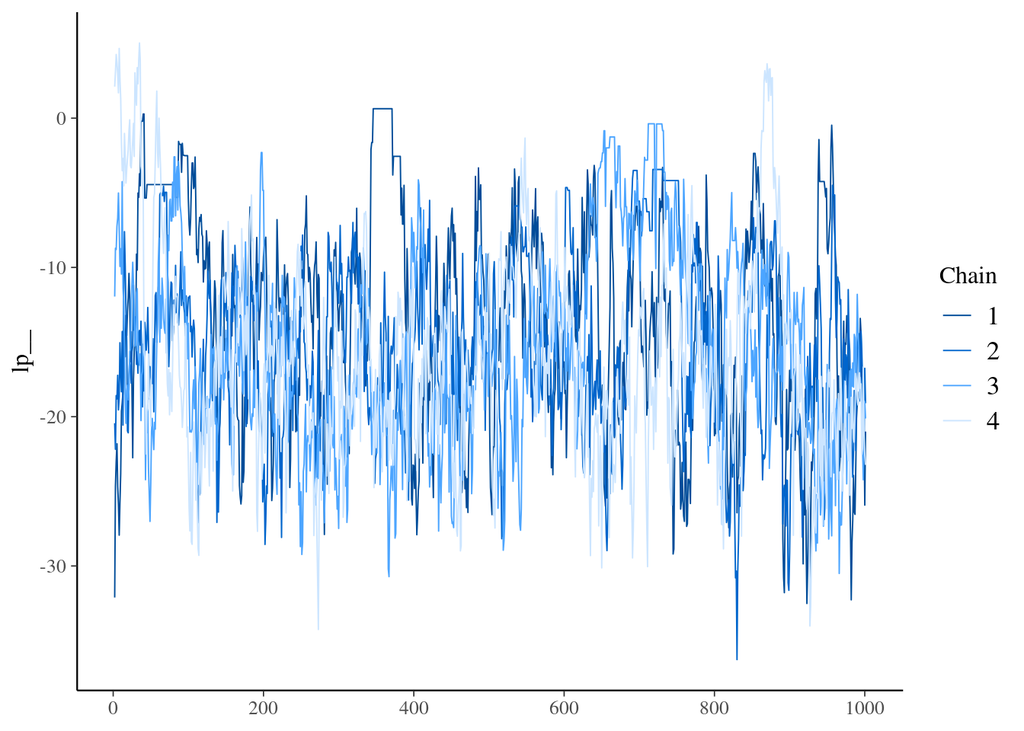

```r
p1 <- mcmc_trace(fit1_stan$draws("lp__"), iter1 = 1) #c("lp__", "phi[1]", "lambda[1]", "theta1[1]")
print(p1)
```

**Scatter plot also showing divergences**

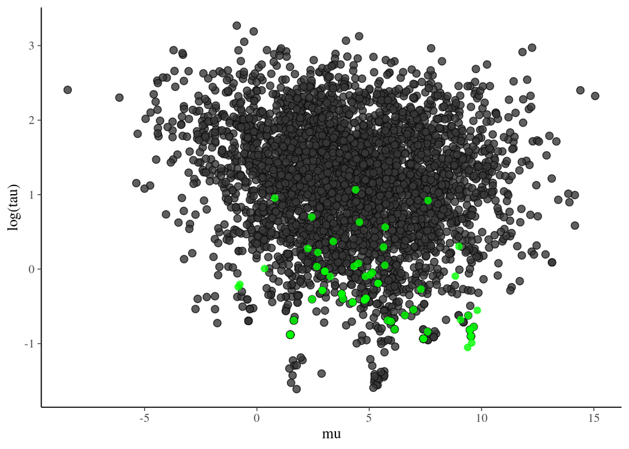

```r
color_scheme_set("darkgray")
mcmc_scatter(
  fit1_stan$draws(),
  pars = c("mu", "tau"),
  transform = list(tau = "log"),
  np = nuts_params(fit1_stan),
  np_style = scatter_style_np(div_color = "green", div_alpha = 0.8)
)
```

**Pairwise scatter plots showing divergences**

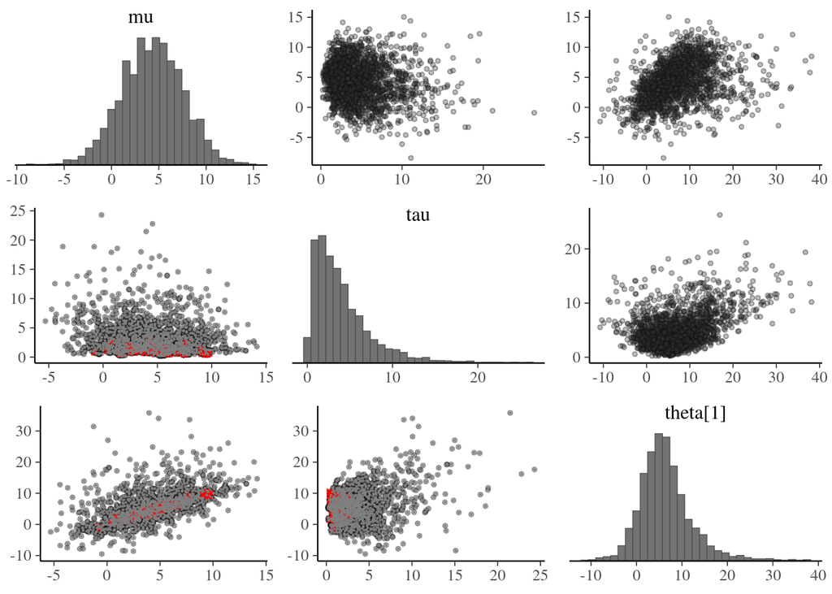

```r
# split the draws according to above/below median accept_stat__
# and show approximate location of divergences (red points)
mcmc_pairs(
  fit1_stan$draws(),
  pars = c("mu", "tau", "theta[1]"),
  off_diag_args = list(size = 1, alpha = 1/3),
  condition = pairs_condition(nuts = "accept_stat__"),
  np = nuts_params(fit1_stan)
)
```

# 4 More resources for beginners

There are many resources available for beginners to learn Stan. Some of the most helpful resources include:

1. The Stan website [(https://mc-stan.org/)](https://mc-stan.org/), which provides detailed documentation, tutorials, and examples of how to use Stan.
2. The Stan User’s Guide [(https://mc-stan.org/users/documentation/)](https://mc-stan.org/users/documentation/), which is an in-depth guide to the Stan programming language and the various features of the software.
3. The Stan Case Studies [(https://mc-stan.org/users/documentation/case-studies.html)](https://mc-stan.org/users/documentation/case-studies.html), which collects case studies to reflect best practices in Bayesian methodology and Stan programming.
4. The Stan Forums [(https://discourse.mc-stan.org/)](https://discourse.mc-stan.org/), which are a community-driven platform for discussing Stan and getting help with Stan-related questions.
5. Online courses and tutorials, such as those offered by DataCamp [(https://www.datacamp.com/courses/introduction-to-stan)](https://www.datacamp.com/courses/introduction-to-stan) and Coursera [(https://www.coursera.org/courses?query=stan)](https://www.coursera.org/courses?query=stan).
6. Books and articles on Stan, such as “Bayesian Data Analysis” by Andrew Gelman et al. and “Doing Bayesian Data Analysis” by John Kruschke.

In general, the best way to learn Stan is to start by working through some of the tutorials and examples provided by the Stan website, and then to practice by working on your own projects and seeking help from the Stan community when you need it.